# Feature Selection with Correlation

```python
# Import libraries
from sklearn.datasets import load_boston
import pandas as pd
import matplotlib.pyplot as plt
%matplotlib inline
```

```python
#Loading data set
data=load_boston()
df=pd.DataFrame(data.data,columns=data.feature_names)
df["MEDV"]=data.target
```

[output not shown]

```python
df.head()
```

|  | CRIM | ZN | INDUS | CHAS | NOX | RM | AGE | DIS | RAD | TAX | PTRATIO | B | LSTAT | MEDV |
| --- | --- | --- | --- | --- | --- | --- | --- | --- | --- | --- | --- | --- | --- | --- |
| 0 | 0.00632 | 18.0 | 2.31 | 0.0 | 0.538 | 6.575 | 65.2 | 4.0900 | 1.0 | 296.0 | 15.3 | 396.90 | 4.98 | 24.0 |
| 1 | 0.02731 | 0.0 | 7.07 | 0.0 | 0.469 | 6.421 | 78.9 | 4.9671 | 2.0 | 242.0 | 17.8 | 396.90 | 9.14 | 21.6 |
| 2 | 0.02729 | 0.0 | 7.07 | 0.0 | 0.469 | 7.185 | 61.1 | 4.9671 | 2.0 | 242.0 | 17.8 | 392.83 | 4.03 | 34.7 |
| 3 | 0.03237 | 0.0 | 2.18 | 0.0 | 0.458 | 6.998 | 45.8 | 6.0622 | 3.0 | 222.0 | 18.7 | 394.63 | 2.94 | 33.4 |
| 4 | 0.06905 | 0.0 | 2.18 | 0.0 | 0.458 | 7.147 | 54.2 | 6.0622 | 3.0 | 222.0 | 18.7 | 396.90 | 5.33 | 36.2 |

# CORRELATION - RULE

IMPORTENT THING IS THAT : If independent feature is highly correlated with dependent feature we need not remove those kind of feature .beacuse those features can play very importent role when we are training our machine learning modeles . But if we have independent feature like (X,Y,Z) this three are highly correlated with each other by more than 90%, then from this three i can just be using one .

```python
# Independent and dependent feature
x=df.drop("MEDV",axis=1)#Feature matrix
y=df["MEDV"]
```

For prevent the overfitting we will be actually doing a train test split

```python
# Train test split
from sklearn.model_selection import train_test_split
x_train,x_test,y_train,y_test=train_test_split(x,y,test_size=0.3,random_state=0)
x_train.shape,x_test.shape
```

```
((354, 13), (152, 13))
```

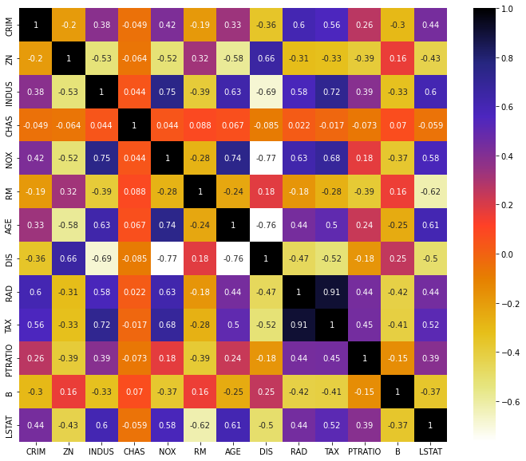

```python
import seaborn as sns
#Using pearson correlation
plt.figure(figsize=(12,10))
cor=x_train.corr()
sns.heatmap(cor,annot=True,cmap=plt.cm.CMRmap_r)
plt.show()
```

see here "TAX" and "RAD" re highly correlated 0.91. if i choose my threshold value is 90% then one of them particular feature can be used and one can be dropped.

Now we will try to create a function which is called as correlation : Now inside this function it will take data set like x_train data set and take some threshold value [ threshold value should be atleast 70%] . inside this we are going to traverse through all the correlation matrix colummn [ check correlation with each and every feature ]

and try to find out correlation is greater than threshold value

```python
def correlation(dataset,threshold):
    col_corr=set()# Set of all names of correlated columns
    corr_matrix=dataset.corr()
    for i in range(len(corr_matrix.columns)):
        for j in range(i):
            if abs(corr_matrix.iloc[i,j])>threshold:  # here taking absolute value of correlation
                colname=corr_matrix.columns[i]
                col_corr.add(colname)

    return col_corr
```

```python
corr_features=correlation(x_train,0.7) # Take threshold value 0.7
corr_features
```

```
{'AGE', 'DIS', 'NOX', 'TAX'}
```

REMEMBER: This process i will not do for x_test . this corelation will only be done in x_train , suppouse i found 3 feature are highly correlated , then we'll remove that 3 feature x_train and x_test also . That is how we are preventing overfitting

```python
x_train.drop(corr_features,axis=1)
```

|  | CRIM | ZN | INDUS | CHAS | RM | RAD | PTRATIO | B | LSTAT |
| --- | --- | --- | --- | --- | --- | --- | --- | --- | --- |
| 141 | 1.62864 | 0.0 | 21.89 | 0.0 | 5.019 | 4.0 | 21.2 | 396.90 | 34.41 |
| 272 | 0.11460 | 20.0 | 6.96 | 0.0 | 6.538 | 3.0 | 18.6 | 394.96 | 7.73 |
| 135 | 0.55778 | 0.0 | 21.89 | 0.0 | 6.335 | 4.0 | 21.2 | 394.67 | 16.96 |
| 298 | 0.06466 | 70.0 | 2.24 | 0.0 | 6.345 | 5.0 | 14.8 | 368.24 | 4.97 |
| 122 | 0.09299 | 0.0 | 25.65 | 0.0 | 5.961 | 2.0 | 19.1 | 378.09 | 17.93 |
| ... | ... | ... | ... | ... | ... | ... | ... | ... | ... |
| 323 | 0.28392 | 0.0 | 7.38 | 0.0 | 5.708 | 5.0 | 19.6 | 391.13 | 11.74 |
| 192 | 0.08664 | 45.0 | 3.44 | 0.0 | 7.178 | 5.0 | 15.2 | 390.49 | 2.87 |
| 117 | 0.15098 | 0.0 | 10.01 | 0.0 | 6.021 | 6.0 | 17.8 | 394.51 | 10.30 |
| 47 | 0.22927 | 0.0 | 6.91 | 0.0 | 6.030 | 3.0 | 17.9 | 392.74 | 18.80 |
| 172 | 0.13914 | 0.0 | 4.05 | 0.0 | 5.572 | 5.0 | 16.6 | 396.90 | 14.69 |

354 rows × 9 columns

```python
x_test.drop(corr_features,axis=1)
```

|  | CRIM | ZN | INDUS | CHAS | RM | RAD | PTRATIO | B | LSTAT |
| --- | --- | --- | --- | --- | --- | --- | --- | --- | --- |
| 329 | 0.06724 | 0.0 | 3.24 | 0.0 | 6.333 | 4.0 | 16.9 | 375.21 | 7.34 |
| 371 | 9.23230 | 0.0 | 18.10 | 0.0 | 6.216 | 24.0 | 20.2 | 366.15 | 9.53 |
| 219 | 0.11425 | 0.0 | 13.89 | 1.0 | 6.373 | 5.0 | 16.4 | 393.74 | 10.50 |
| 403 | 24.80170 | 0.0 | 18.10 | 0.0 | 5.349 | 24.0 | 20.2 | 396.90 | 19.77 |
| 78 | 0.05646 | 0.0 | 12.83 | 0.0 | 6.232 | 5.0 | 18.7 | 386.40 | 12.34 |
| ... | ... | ... | ... | ... | ... | ... | ... | ... | ... |
| 4 | 0.06905 | 0.0 | 2.18 | 0.0 | 7.147 | 3.0 | 18.7 | 396.90 | 5.33 |
| 428 | 7.36711 | 0.0 | 18.10 | 0.0 | 6.193 | 24.0 | 20.2 | 96.73 | 21.52 |
| 385 | 16.81180 | 0.0 | 18.10 | 0.0 | 5.277 | 24.0 | 20.2 | 396.90 | 30.81 |
| 308 | 0.49298 | 0.0 | 9.90 | 0.0 | 6.635 | 4.0 | 18.4 | 396.90 | 4.54 |
| 5 | 0.02985 | 0.0 | 2.18 | 0.0 | 6.430 | 3.0 | 18.7 | 394.12 | 5.21 |

152 rows × 9 columns